# Stream and Process Live Tweets

### 1. Introduction.

Twitter is a social networking platform where users can post messages related to entertainment, current events, news and politics, and other forms of information by creating "Tweets". Twitter users can also interact with each other by replying or retweeting tweets. Twitter has become a platform to many important discourse in relation to politics, science, technology, popular culture, and social movements since it was founded in 2006.

Since the beginning of big data revolution in the 21st century, taking data has become very easy. Twitter data can be mined through its Application Programming Interface (API) but with limits ( see [rate-limits](https://developer.twitter.com/en/docs/basics/rate-limits.html) ). There are multiple ways you can mine twitter data but the easiest way possible is using the python NLTK module ( [NLTK](https://www.nltk.org/) ) which will be discussed in Section 3.

**GITHUB.** raw-data-twitter-tweets

**Purpose.** The scripts on this repository provides an easy way to stream, filter, and process live tweets iteratively for researchers interested in data science, mathematical modeling, computational linguistics, historical linguistics, and/or discourse analysis. This repository lets you stream live tweets via using the Natural Language Processing Tool Kit (NLTK) developed by Bird et. al. [1]. The code is designed to capture $n$ tweets in a way such that it streams continuously until a specified time. The streamer uses a list of keywords to capture tweets that matches those keywords.

After successful streaming, the code will filter the tweets to reduce the memory size. Processing is done separately to choose which time range to process.

**Warning.** Streaming live tweets for long periods is not recommended because the filesize gets very large unless you have reasonable file storage. The streamer also can capture any public tweets (protected tweets are not captured). That means it can capture, tweets from bot users, pornography, and profanity; when viewing these tweets, it might be NSFW.

### 2. Just Give Me the Data.

**Data Downloads.** If you want the preprocessed datasets you can download them in these following links.

**NOTE.** The time stamps of each tweet is in Universal Coordinated Time (UTC) but the labels of the files below is in Pacific Standard Time (PST).

**Step I: Raw Data.** Request by Email (Raw) September 2017 to October 2017 (31.04GB)

**Step II: Filtered Data.** Request by Email (Filtered) September 2017 to October 2017 (8.54GB)

**Step III: Processed Data.** Request by Email (Processed) September 2017 to October 2017 (6.04GB)

**Step IV: Tabulated Data.** This is the processed data converted into table form. [(Tabulated) September 2017 to October 2017 (3.38GB)](https://drive.google.com/open?id=13WsCp1kzLXKkhzyZpTEzoTfflI5V3-pf)

**Step V: Subsets and Merged Subsets.** This is the tabulated data selecting only related tweets according to some selected hashtags.

1. [(Subset) September 2017 to October 2017 (412.10MB)](https://drive.google.com/open?id=1lCmrIByasBjOFKE6egNV1VYmUq-j9H_t)
2. [(Merged Subset) September 2017 to October 2017 (404MB)](https://drive.google.com/open?id=1pWqnDOpbp7vegr3ThItmqt5L6OYBnB7E)

**Data tabulation and subsetting.** The raw Twitter data collected during live streaming was processed in five steps. The first step is when the raw data is saved into a JSON file and processed through a filter and processing steps where the unecessary information (such as hyperlinks and empty strings) are filtered away. The last two steps are the conversion from JSON data structure to a tabular data structure for easy access of information. Tabulating and subsetting is discussed in Section 4.

**Subset information.** The subset datasets are with tweets that contain and relate to the following hashtags (lowercased).

```
takeaknee
taketheknee
prayforvegas
metoo
```

**Table Column Descriptions.**

```
# *-tweet.csv.gz file: (Table of tweet information where each row is a unique tweet)
#   1.  TID    - Tweet ID (always unique)
#   2.  RTT    - Retweeted Tweets (1-True or 0-False)
#   3.  RPT    - Replied Tweets (1-True or 0-False)
#   4.  TRP    - Tweet Replies (1-True or 0-False)
#   5.  NRT    - Normal Tweets (1-True or 0-False)
#   6.  PTID   - Parent Tweet ID (replies only)
#   7.  UID    - User ID
#   8.  USN    - User screen name
#   9.  TM     - Time created
#   10. RPC    - Replied Counts
#   11. FVC    - Favorited Counts
#   12. RTC    - Retweeted Counts
#   13. L      - language
#   14. TXT    - Tweet Text
#   15. HTGS   - Hashtags (sep=',')
#   16. UMS    - user mentions (sep=',')
#   17. TMRT   - Time if retweeted (sep=',')
#   18. RPCRT  - Replied Counts if retweeted (sep=',')
#   19. FVCRT  - Favorited Counts if retweeted (sep=',')
#   20. RTCRT  - Retweeted Counts if retweeted (sep=',')
#   21. UIDRT  - User ID if retweeted (sep=',')
#   22. USNRT  - User screen name if retweeted (sep=',')

# *-user.csv.gz file: (table of user information where each row is a unique user)
#   1. UID  - User ID
#   2. USN  - User screen name [OMITTED]
#   3. UT   - Time user created
#   4. UNFL - User number of followers (sep=',')
```

```python
import matplotlib.pyplot as plt
import customPlot as cp
import twitter as tw
import numpy as np
import pandas as pd
```

#### 2.1 Reading Processed Data (September 23-24, 2017).

As an example, we use the subset tweets taken from 09/23/2017-09/24/2017 (PST) [09/24/2017-09/25/2017 (UTC)]. The python script below reads the data set.

```python
stream = 'A'
date_range = '09232017-09242017'
T, U = tw.read_csv(stream,date_range,dtype=str,subset=False,
                   which_set='merged',which_set_params=['hashtag','a'])
```

#### 2.2 Time-line of Twitter Counts.

The datasets are tweets observed while a user either tweets or retweets while the live streamer was turned on. If a user retweets a tweet a few days ago while the streamer was on, then the streamer can capture the retweet and the original tweet. Similar to when a user tweets a reply to a tweet.

We can visualize the time-line (universal coordinated time UTC) of counts using the script below.

```python
bins_u, bins_c, hour_label, day_label = tw.time_binner(T,by='hour')
```

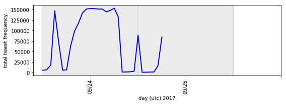

```python
# figure twitter counts by hour
fig, ax = plt.subplots(1,1,figsize=(8,3))
total_counts = list(bins_c.values())
ax.axvspan(0,len(hour_label[0]),alpha=0.15,color='gray')
for t in range(0,len(total_counts)+1):
    if t%24 == 0:
        ax.axvline(t,alpha=0.10,color='black')
ax.plot(range(0,len(total_counts)),total_counts,'-',linewidth=2,color='blue')
ax.set_xticks(day_label[1])
ax.set_xticklabels(day_label[0],rotation=90)
ax.set_xlabel('day (utc) 2017')
ax.set_ylabel('total tweet frequency')
plt.tight_layout()
plt.show()
```

#### 2.3 Counting the Number of Tweets by Category.

There are four categories of tweets.

1. **Normal.** A set of tweets with no replies and it was never retweeted during streaming. Since these tweets are streamed live, the number of likes, retweeted counts, and reply counts are expected to be zero.
2. **Replied.** A set of tweets that have at least one observed reply. We call the replied tweet as a parent tweet with children as the replies. Only when we stream a reply, we can record a nonzero likes, retweeted counts, and reply counts if any. There some replied tweets with no tweet and user id due to the lack of information from the raw data.
3. **reply.** These are a set of tweets that are replies to tweets. These are the children tweets of the parent tweets. A tweet reply can also be a parent tweet. There some tweet replies with parent tweet with only tweet id information.
4. **Retweets.** These are the tweets that are retweeted/replicated at least once. A retweet can also be a parent tweet.

We can visualize these sets by using the script below.

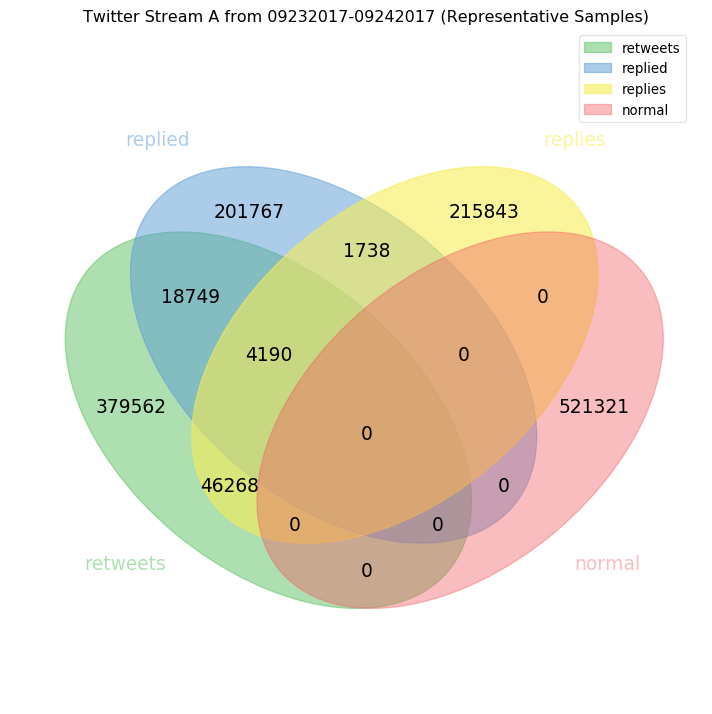

```python
T_categories = tw.tweet_id_categories(T,dtype=str)
info_labels = list(T_categories.keys())
info_sets = [T_categories[i] for i in info_labels]
sets = cp.get_labels(info_sets, fill=['number'])
cp.venn4(sets,names=info_labels,figsize=(9,9))
plt.title('Twitter Stream '+stream+' from '+date_range+' (Representative Samples)')
plt.show()
```

#### 2.4 Getting Random tweets from a category.

*Getting random normal tweet information.*

```python
NRT_ids = T.index[T['NRT'] == '1'].tolist()
T.loc[np.random.choice(NRT_ids,size=10,replace=False),['TM','RPC','FVC','RTC','TXT','TMRT']]
```

|  | TM | RPC | FVC | RTC | TXT | TMRT |
| --- | --- | --- | --- | --- | --- | --- |
| 911896936394960896 | Sep 24 2017 10:15:46 +0 | 0 | 0 | 0 | Love Island girls 'competing for spot on I'm A... | * |
| 911952716779229186 | Sep 24 2017 13:57:25 +0 | 0 | 0 | 0 | 和訳できます！ 『（コⅠ356）WORLD TREK English Communicati... | * |
| 912019204865511424 | Sep 24 2017 18:21:37 +0 | 0 | 0 | 0 | Pero no podés ser así vieja.. ya está | * |
| 911912208292081664 | Sep 24 2017 11:16:27 +0 | 0 | 0 | 0 | You have three choices in life: give in, give ... | * |
| 912032211494465536 | Sep 24 2017 19:13:18 +0 | 0 | 0 | 0 | NIB $520 Alexander Wang Ash High Burned Black ... | * |
| 911931204261306373 | Sep 24 2017 12:31:56 +0 | 0 | 0 | 0 | In the rocks of Libya, they have discovered an... | * |
| 911807082172682240 | Sep 24 2017 04:18:43 +0 | 0 | 0 | 0 | New day, new tweets, new stats. 1 new unfollow... | * |
| 912027706744868865 | Sep 24 2017 18:55:24 +0 | 0 | 0 | 0 | Now i know i’ve met an angel in person 🎶💙 | * |
| 911942196940754944 | Sep 24 2017 13:15:37 +0 | 0 | 0 | 0 | Relationship goals | * |
| 911964735779868675 | Sep 24 2017 14:45:11 +0 | 0 | 0 | 0 | He’s so shy and always looks so sad, but he’s ... | * |

*Getting random retweeted tweet information.*

```python
RTT_ids = T.index[T['RTT'] == '1'].tolist()
T.loc[np.random.choice(RTT_ids,size=10,replace=False),['TM','RPC','FVC','RTC','TXT','TMRT']]
```

|  | TM | RPC | FVC | RTC | TXT | TMRT |
| --- | --- | --- | --- | --- | --- | --- |
| 911510608536674305 | Sep 23 2017 08:40:38 +0 | 0 | 1 | 8 | @bernardokath LOVE YOU KATH!! 😍❤ #PushAwardsKa... | Sep 24 2017 03:21:32 +0 |
| 911973281342922757 | Sep 24 2017 15:19:08 +0 | 0 | 0 | 1 | #Asamblea24S La sociedad se manifiesta en la c... | Sep 24 2017 15:20:49 +0 |
| 911625189619879936 | Sep 23 2017 16:15:57 +0 | 6 | 437 | 232 | People who are well liked: 1 ask for nothing 2... | Sep 24 2017 08:31:09 +0 |
| 911813974555004928 | Sep 24 2017 04:46:06 +0 | 0 | 0 | 1 | Saw the vineyard vines shirt and quit listening | Sep 24 2017 07:39:32 +0 |
| 911919080000692229 | Sep 24 2017 11:43:45 +0 | 1 | 3 | 9 | Robert Maxwell. War criminal. Stole millions o... | Sep 24 2017 12:19:04 +0 |
| 911653652326174722 | Sep 23 2017 18:09:03 +0 | 21 | 395 | 146 | Irving Berlin: The Story of the Man Behind 'Go... | Sep 24 2017 03:51:36 +0,Sep 24 2017 11:06:26 +0 |
| 911794558509486081 | Sep 24 2017 03:28:57 +0 | 2 | 58 | 124 | I love twitter | Sep 24 2017 04:05:28 +0,Sep 24 2017 12:36:40 +... |
| 911750788111900672 | Sep 24 2017 00:35:02 +0 | 0 | 9 | 2 | This kid...kicking butt is just what she does ... | Sep 24 2017 03:48:38 +0 |
| 912030055966154752 | Sep 24 2017 19:04:44 +0 | 0 | 2 | 2 | BREAKFAST is the most important meal of the da... | Sep 24 2017 19:07:36 +0 |
| 910899046990061569 | Sep 21 2017 16:10:31 +0 | 1 | 519 | 1385 | (🌸💛) LED ซัพพอร์ตวันเกิดควานลินจาก Sea Salt &a... | Sep 24 2017 13:34:29 +0,Sep 24 2017 13:40:54 +... |

*Getting random replied tweets information.*

```python
RPT_ids = T.index[T['RPT'] == '1'].tolist()
T.loc[np.random.choice(RPT_ids,size=10,replace=False),['TM','RPC','FVC','RTC','TXT','TMRT']]
```

|  | TM | RPC | FVC | RTC | TXT | TMRT |
| --- | --- | --- | --- | --- | --- | --- |
| 911958556034834434 | * | * | * | * | * | * |
| 911728447080194048 | * | * | * | * | * | * |
| 911858725702451202 | * | * | * | * | * | * |
| 912100138151157760 | * | * | * | * | * | * |
| 911930056053805056 | * | * | * | * | * | * |
| 911958669213958144 | * | * | * | * | * | * |
| 911969029220392969 | * | * | * | * | * | * |
| 911678477446893570 | Sep 23 2017 19:47:41 +0 | 12 | 34 | 26 | NFL's Goodell: Trump's 'Divisive' Comment Show... | Sep 24 2017 04:03:25 +0 |
| 912022590662807553 | Sep 24 2017 18:35:04 +0 | 11 | 302 | 90 | RT if you're done with BOOST and ready for the... | Sep 24 2017 18:57:46 +0,Sep 24 2017 19:03:12 +... |
| 911913214077734913 | * | * | * | * | * | * |

*Getting random tweet replies information.*

```python
TRP_ids = T.index[T['TRP'] == '1'].tolist()
T.loc[np.random.choice(TRP_ids,size=10,replace=False),['TM','RPC','FVC','RTC','TXT','TMRT']]
```

|  | TM | RPC | FVC | RTC | TXT | TMRT |
| --- | --- | --- | --- | --- | --- | --- |
| 912015103117193223 | Sep 24 2017 18:05:19 +0 | * | * | * | @AzteckSmite @PotatoDotNet @CriimsonA And imo ... | * |
| 911907447954116608 | Sep 24 2017 10:57:32 +0 | * | * | * | @Jeff_Davis20 @Annabelle4SC @realDonaldTrump @... | * |
| 912028726401032192 | Sep 24 2017 18:59:27 +0 | * | * | * | @JLJeffLewis Oh my gosh. I don't think I have ... | * |
| 911912938138615808 | Sep 24 2017 11:19:21 +0 | 0 | 1 | 1 | @LisaD787 @brushhandsigns @janjewson1 @unholyc... | Sep 24 2017 11:20:30 +0 |
| 912014065370877954 | Sep 24 2017 18:01:12 +0 | * | * | * | @OmnivoreBlog I don't refuse business to anyon... | * |
| 911797502613102592 | Sep 24 2017 03:40:39 +0 | * | * | * | @sandyhair1968 Why on earth would you imply th... | * |
| 911973721690312704 | Sep 24 2017 15:20:53 +0 | 16 | 376 | 190 | @JColeNC Rt it jcole is the best rapper alive | Sep 24 2017 15:22:52 +0,Sep 24 2017 15:39:30 +... |
| 911899743009349633 | Sep 24 2017 10:26:55 +0 | * | * | * | @HunerPishder1 @BaxtiyarGoran @coalition Poor ... | * |
| 911921515364589568 | Sep 24 2017 11:53:26 +0 | * | * | * | @cupofty Me too man. Think the next ones in No... | * |
| 911945674156998656 | Sep 24 2017 13:29:26 +0 | 0 | 2 | 1 | @realDonaldTrump Koch owned politicians began ... | Sep 24 2017 14:35:03 +0 |

#### 2.5 Getting Random User Information.

The user information is a separate dataset from the tweets. You can reference the 'UID' (user id) from the 'tweet' set to get information about the user in the 'user' set and vice versa.

Note that the 'UNFL' (user number of followers) are in a list structure because it corresponds to the user's tweets. This structure let's us track the change of information when a user tweets something.

```python
user_ids = U['UT'].keys().tolist()
U.loc[np.random.choice(user_ids,size=10,replace=False)]
```

|  | USN | UT | UNFL |
| --- | --- | --- | --- |
| 227919049 | MoonChildTay | Dec 18 2010 05:38:06 +0 | 2188,2188 |
| 355693509 | CataniaAlvarez | Aug 15 2011 19:04:39 +0 | 540 |
| 2664439588 | paulaepatton828 | Jul 02 2014 16:14:41 +0 | 193 |
| 3055422280 | tizerbo | Feb 23 2015 10:08:57 +0 | 67 |
| 711075255956185088 | junglesumatra | Mar 19 2016 06:22:06 +0 | 104 |
| 65237962 | TheMarinersGuy | Aug 13 2009 01:58:00 +0 | 1054 |
| 2315659439 | HebroRican | Jan 31 2014 08:29:29 +0 | 112 |
| 3841669761 | rm2022mr | Oct 02 2015 09:31:16 +0 | 49 |
| 164354823 | BenMank77 | Jul 08 2010 17:34:38 +0 | 64737,64744,64744 |
| 790347651460001792 | yoshi_kidd9999 | Oct 24 2016 00:22:18 +0 | 293 |

#### 2.6 Getting random tweets of a specific user via user id (UID).

```python
# Alyssa_Milano (26642006)
tid = np.random.choice(T.index[T['UID']=='26642006'],size=6,replace=False)
T.loc[tid,['USN','TM','RPC','FVC','RTC','TXT','TMRT']]
```

|  | USN | TM | RPC | FVC | RTC | TXT | TMRT |
| --- | --- | --- | --- | --- | --- | --- | --- |
| 910885842234863617 | Alyssa_Milano | Sep 21 2017 15:18:02 +0 | 20 | 401 | 186 | Hello, @SenWarren and @SenMarkey. This is @Gen... | Sep 24 2017 16:37:07 +0 |
| 911948525872844802 | Alyssa_Milano | Sep 24 2017 13:40:46 +0 | 273 | 11739 | 2684 | BREAKING: Jaguars owner has taken a knee in so... | Sep 25 2017 06:30:50 +0,Sep 24 2017 13:45:08 +... |
| 912006354923081728 | Alyssa_Milano | Sep 24 2017 17:30:33 +0 | 71 | 541 | 120 | Thank you for your leadership, @tedcruz. #Kill... | Sep 24 2017 17:38:19 +0,Sep 24 2017 17:38:50 +... |
| 911811799099613185 | Alyssa_Milano | Sep 24 2017 04:37:28 +0 | 59 | 498 | 370 | 10 Facts everyone needs to know right now abou... | Sep 24 2017 04:37:50 +0,Sep 24 2017 04:39:16 +... |
| 912035983343964160 | Alyssa_Milano | Sep 24 2017 19:28:17 +0 | 2828 | 11148 | 2022 | Thank you, @realDonaldTrump for giving me oppo... | Sep 25 2017 06:25:32 +0,Sep 24 2017 19:28:35 +... |
| 911371949867233280 | Alyssa_Milano | Sep 22 2017 23:29:39 +0 | 122 | 1202 | 704 | #BREAKING: Government notifies 21 states that ... | Sep 24 2017 07:54:45 +0 |

```python
# realDonaldTrump (25073877)
tid = np.random.choice(T.index[T['UID']=='25073877'],size=6,replace=False)
T.loc[tid,['USN','TM','RPC','FVC','RTC','TXT','TMRT']]
```

|  | USN | TM | RPC | FVC | RTC | TXT | TMRT |
| --- | --- | --- | --- | --- | --- | --- | --- |
| 278200675039592448 | realDonaldTrump | Dec 10 2012 18:13:04 +0 | 142 | 4543 | 3580 | @Lord_Sugar Dopey Sugar--because it was open a... | Sep 24 2017 11:41:21 +0 |
| 910447064944955392 | realDonaldTrump | Sep 20 2017 10:14:30 +0 | 7007 | 55990 | 10546 | Big meetings today at the United Nations. So m... | Sep 24 2017 10:45:19 +0,Sep 24 2017 15:36:56 +0 |
| 910580644597649409 | realDonaldTrump | Sep 20 2017 19:05:18 +0 | 7385 | 41980 | 9265 | Honored to host a luncheon for African leaders... | Sep 24 2017 03:00:31 +0,Sep 24 2017 13:58:23 +... |
| 905603224379559936 | realDonaldTrump | Sep 07 2017 01:26:48 +0 | 11832 | 60723 | 15270 | We want our companies to hire &amp; grow in AM... | Sep 24 2017 02:58:40 +0,Sep 24 2017 03:03:00 +... |
| 908646582807089152 | realDonaldTrump | Sep 15 2017 11:00:01 +0 | 29276 | 101469 | 21657 | We have made more progress in the last nine mo... | Sep 25 2017 00:42:40 +0 |
| 908642277987356673 | realDonaldTrump | Sep 15 2017 10:42:55 +0 | 19821 | 110353 | 29330 | Another attack in London by a loser terrorist.... | Sep 24 2017 18:59:42 +0 |

### 3. Stream, FIlter and Process Live Tweets.

Using the streamer scripts **streamTwitter.py**, **loop.streamTweets.sh**, and **run.loop.streamTweets.sh** requires two things.

1. The NLTK python modules which is available in this website ( https://www.nltk.org/ ). You can read about it in detail in this book by Bird et. al. [1].
2. Twitter Application Progamming Interface (API) keys.

#### 3.1 Installing the Natural Language Tool Kit (NLTK) and NLTK Corpora.

*Install NLTK using Linux terminal.*

```
sudo pip install -U nltk
```

*Install NLTK Corpora using Python.*

```
import nltk
nltk.download()
```

#### 3.2 Setting Up the Twitter Application Programming Interface (API).

You can follow the NLTK instructions for setting up the API here ( [NLTK](http://www.nltk.org/howto/twitter.html) ) but essentially it comes down into three steps.

- **Step 1.** Create a Twitter account ( [twitter.com](https://twitter.com/?lang=en) )
- **Step 2.** Apply for a developer account - standard API ( [developer.twitter.com](https://developer.twitter.com/en/apply-for-access) )
- **Step 3.** Copy your keys in the format - shown below - while saving it into a text file named *credentials.txt*. Create a folder/directory *twitter-files* in your home directory and place the text file into that new folder.

```
app_key=[key]
app_secret=[secret]
oauth_token=[token]
oauth_token_secret=[secret token]
```

#### 3.3 Streaming and Filtering Live Tweets.

Before you can stream, you need to provide a list of keywords. The NLTK streamer requires a list of keywords to capture live tweets with those keywords.

For example you need to create a text file named *keywords-stream[X].txt* in the *keywords-stream* folder where **[X]** is the whatever you want to name your list. Then, list all the keywords inside the text file like shown below.

```
normal
abnormal
supernormal
unnormal
binormal
mononormal
uninormal
homonormal
heteronormal
```

Next, edit the lines shown below of the bash script **run.loop.streamTweets.sh**. The *path_twitterFiles* variable is the absolute path to the **credentials.txt** file. The *STDVID* is the name of your list **[X]**. Below is an example where we tell the streamer to take 4000 tweets for every loop until August 14, 2018 at 6:14 pm (the time is in 24-hour format). If the entered time is in the past, then the loop will just immediately stop upon execution.

```
path_twitterFiles="/home/[username]/twitter-files"

STDVID=[X]
stopDay=14
stopMonth=08
stopYear=2018
stopHour=18
stopMinute=14
tweetsPerLoop=4000
```

Save the updated **run.loop.streamTweets.sh** and run it using the command below on linux terminal. The streamer saves the tweets every loop and filters and compresses the tweets every day and for every month.

```
./run.loop.streamTweets.sh
```

#### 3.4 Processing Live Tweets.

Make sure you have the compressed filtered data in the **[X]-filtered** folder where **[X]** is the name of the keywords list. The streamer saves the tweets in JSON format ( you can see an overview of the JSON data structure here ( tweet-object ).

The processor will process the JSON file such that it takes in information and converts it into a python dictionary data structure for easy access. The advantage of this data structure is that we can track connected tweets (i.e. replies and retweets to the a parent tweet) more easily than dealing with the JSON files directly.

To process the streamed tweets, use the **processTweets.sh** bash file. This file takes in three arguments.

1. **[X]** $\rightarrow$ The name of the keyword list.
2. An array of specified dates you want to process.
3. The number of cores you want use (the code is paralellized in a multi-threading fasion where it can process $n$ tweets at a time).

Use the example bash script below where it will process the data set using the A keyword list from September 23, 2017 to September 24, 2017 and using 3 cores. The processed tweets is saved into **[X]-processed** folder.

*Download Filtered Data First (see Section 2).*

```
STDVID=A
dates=("09232017" "09232017")
./processTweets.py ${STDVID} "${dates[*]}" 3
```

```
STDVID=A
dates=("09232017" "09242017")
./processTweets.py ${STDVID} "${dates[*]}" 3
```

### 4. Tabulate and Subset Tweets.

#### 4.1. Tabulating Tweets.

Make sure you have the processed data in the **[X]-processed** where **[X]** is the name of the keywords list.

Use the example bash script below where it will tabulate the processed data using A keyword list from September 23, 2017 to September 24, 2017. The tabulated tweets is saved into **[X]-tabulated** folder.

*Download Processed Data First (see Section 2).*

```
./tabulateTweets.py 'A' '09232017-09232017'
./tabulateTweets.py 'A' '09232017-09242017'
```

#### 4.2. Subsetting Tabulated Tweets.

Create a folder named **keywords-subset** and make a text file named **keywords-[F]-[Y].txt** where **[F]** is the column to filter and **[Y]** is for whatever you want to name your keyword subset list. Then, list all the keywords like shown below or the hashtag list in Section 2.

```
hashtag
love
hate
```

*Download Tabulated Data First (see Section 2).*

```
./indexTweets.py 'A' 'hashtag' 'a' '09232017-09242017' 100000 '09232017-09242017'
./subsetTweets.py 'A' 'hashtag' 'a' '09232017-09232017' 100000 '09232017-09242017'
./subsetTweets.py 'A' 'hashtag' 'a' '09232017-09242017' 100000 '09232017-09242017'
./mergeTweets.py 'A' 'hashtag' 'a' '09232017-09242017'
```

### References

1. Bird, Steven, Ewan Klein, and Edward Loper. Natural language processing with Python: analyzing text with the natural language toolkit. " O'Reilly Media, Inc.", 2009.